# Final Project

Tanya Wang

# How Languages Spoken Affect English Ability

You can find this project and the datsets I used at the following github.io website: “https://twang53.github.io/STAT184_FinalProject/”

## Introduction

### Research Question

#### **How does the number of people who speak a langauge affect their English speaking ability?**

I want to see how the number of peopel who speak a certain language at home can affect a person’s ability to speak English well. If possible, I will also try seeing if there is a correlation between type of language and English speaking ability. This is really interesting for me because I’ve always been interested in the linguistics field and I thought it would be cool to see if there was some trend in the number of languages (types of languages) spoken at home versus self-reported English speaking ability. Ideally, we’d like a scientific output for Englihs speaking ability for each person based on statistical analysis of their responses to different tasks, but the data I got from the Census doesn’t have that since this pattern I’m looking for wasn’t what they originally collected the data for.

From experience when I submitted my preliminary EDA, I found out that I had to significanctly dial down the number of data tables I wanted to use since the data is not formatted in a way that is easily usable by R. I decided to stick with only a couple of states from the datasets by state since that in itself is a lot of data to clean, wrangle, and such. I also decided to add in another dataset for the entire US nation itself to see if the same trend we might see in states may also be true for the entire nation as a whole.

## The Data

First we need to clean the environment and then load the package(s) we need. There are some packages that requiring installing, but I have commented them out after I have installed it once so that the code doesn’t run but you can see what packages I needed to install. Below is a description of each package I loaded and what it is used for:

- **tidyverse:** this is a collection of R packages designed for data science. It includes ggplot2, dplyr, tidyr, and more that we can use for everyday data analyses.
- **readxl:** this package makes it easy to get data out of Excel and into R
- **naniar:** contains tools for exploring missing data structures with minimal deviation from the common workflows of ggplot & tidy data
- **datasets:** contains tons of data the user can load and use immediately (in case I need it at some point)

```r
# This cleans up the environment.
rm(list = ls())

# Install necessary packages.
# install.packages("naniar")

# This loads the packages we need.
library(tidyverse)
library(readxl)
library(naniar)
library(datasets)
```

### Loading the Data

Now we read in our data from the xls file. This one is for **states in the US and contains 52 data tables**, all in separate sheets (because it contains Puerto Rico as well). This data was taken from the Census Bureau website.  
Let’s start off with just one state.

```r
# Specifying Data Path (change path as needed since this is specific to where the data is saved on my laptop)
xls_data <- "C:/Users/GuaiGuai/Documents/R/STAT184_FinalProject/2009-2013-acs-lang-tables-state.xls"

# This returns the names of all the sheets in our xls file (for future reference).
excel_sheets(path = xls_data)
```

```
 [1] "Contents"             "Alabama"              "Alaska"               "Arizona"
 [5] "Arkansas"             "California"           "Colorado"             "Connecticut"
 [9] "Delaware"             "District of Columbia" "Florida"              "Georgia"
[13] "Hawaii"               "Idaho"                "Illinois"             "Indiana"
[17] "Iowa"                 "Kansas"               "Kentucky"             "Louisiana"
[21] "Maine"                "Maryland"             "Massachusetts"        "Michigan"
[25] "Minnesota"            "Mississippi"          "Missouri"             "Montana"
[29] "Nebraska"             "Nevada"               "New Hampshire"        "New Jersey"
[33] "New Mexico"           "New York"             "North Carolina"       "North Dakota"
[37] "Ohio"                 "Oklahoma"             "Oregon"               "Pennsylvania"
[41] "Rhode Island"         "South Carolina"       "South Dakota"         "Tennessee"
[45] "Texas"                "Utah"                 "Vermont"              "Virginia"
[49] "Washington"           "West Virginia"        "Wisconsin"            "Wyoming"
[53] "Puerto Rico"
```

Let’s start with an example: **Alabama**. I will take you through my process of loading and cleaning the data.

```r
# I specified which sheet I want by it's name and made sure to set the na argument because some of the cells are empty but represented by "--", rather than a blank cell. I will deal with the cells with letters in them later.
Alabama <- read_excel(path = xls_data, sheet = "Alabama", na = "--")


# Let's see what the data looks like at first so that we know what kind of cleaning we need to do.

# View(Alabama) --> This code is commented out because View() should not be put in a markdown file and was a function I used in the console to check my data. I just wanted to add it here initially so you know I was checking my entire table. For the rest of the markdown file, I will not be including View() functions, even if I run them in the console.

head(Alabama)
```

| Table with column headers in row 5 and row headers in column A | ...2 | ...3 | ...4 | ...5 |
| --- | --- | --- | --- | --- |
| Table 1. Detailed Languages Spoken at Home and Ability to Speak English for the Population 5 Years and Over for Alabama: 2009-2013 | NA | NA | NA | NA |
| Release Date: October 2015 | NA | NA | NA | NA |
| NA | NA | NA | NA | NA |
| NA | Number of speakers1 | Margin of Error2 | Speak English less than "Very Well"1 | Margin of Error2 |
| Population 5 years and over | 4497352 | 490 | 107436 | 2608 |
| Speak only English at home | 4261611 | 3627 | (X) | (X) |

### Clean the Data

```r
# I need to rename the variables (columns) first to sort out what I'm looking at.
names(Alabama)[c(1, 2, 3, 4, 5)] <- c("Language", "NumberSpeakers", "SpeakersError", "EnglishNotVeryWell", "EnglishError")

# Now I need to filter the data initially so I get my first couple of rows. I will filter out more rows after this.
Alabama <-
  Alabama %>%
  filter(row_number() > 5, row_number() < 144)


# I used replace_with_na from the naniar package to replace certain values with NA based on the descriptions for the data I received. This will make cleaning up data a bit easier later when I get rid of cases that contain all NA values.

# According to the dataset, (D) stands for data withheld to avoid disclosure, (B) stands for either no sample observations or too few sample observations were available to compute an estimate, and (X) stands for that the question does not apply.
Alabama <-
  Alabama %>% replace_with_na(replace = list(NumberSpeakers = c("(D)", "(B)", "(X)"), SpeakersError = c("(D)", "(B)", "(X)"), EnglishNotVeryWell = c("(D)", "(B)", "(X)"), EnglishError = c("(D)", "(B)", "(X)")))

# Check to see if my cleaning did anything.
head(Alabama)
```

| Language | NumberSpeakers | SpeakersError | EnglishNotVeryWell | EnglishError |
| --- | --- | --- | --- | --- |
| Speak only English at home | 4261611 | 3627 | NA | NA |
| Speak a language other than English at home | 235741 | 3580 | 107436 | 2608 |
| SPANISH AND SPANISH CREOLE | 151384 | 2607 | 78970 | 2312 |
| Spanish | 151385 | 2607 | 78970 | 2312 |
| OTHER INDO-EUROPEAN LANGUAGES | 38001 | 1797 | 7995 | 662 |
| French (incl. Patois, Cajun) | 7379 | 653 | 1190 | 217 |

After the initial filtering, I still need to take out some rows that are just totals (which therefore make the data not tidy). I will also be dropping the cases that have NA values.

```r
# Dropping specific rows
Alabama <-
  Alabama[-c(2, 4, 5, 7:9, 13, 15, 17, 21, 29, 33, 44, 55, 65, 66, 78, 88, 101, 103, 122),]

#Drop the cases with NA values
Alabama <-
  Alabama %>%
  na.omit()

# Check to see if I get the output I want
head(Alabama)
```

| Language | NumberSpeakers | SpeakersError | EnglishNotVeryWell | EnglishError |
| --- | --- | --- | --- | --- |
| SPANISH AND SPANISH CREOLE | 151384 | 2607 | 78970 | 2312 |
| French (incl. Patois, Cajun) | 7379 | 653 | 1190 | 217 |
| French Creole | 333 | 127 | 90 | 68 |
| Italian | 1672 | 293 | 440 | 150 |
| Portuguese (incl. Portuguese Creole) | 1374 | 337 | 421 | 193 |
| German (incl. Luxembourgian) | 10038 | 816 | 1526 | 275 |

Now that we have finished that cleaning, we need to add a new variable to prep this data table for when we append other data tables to it.

```r
# I use mutate() to add a state variable so when we append data tables, we will know which data is from which state.
Alabama <-
  Alabama %>%
  mutate(state = "Alabama")

# Check the data table
names(Alabama)
```

```
[1] "Language"           "NumberSpeakers"     "SpeakersError"      "EnglishNotVeryWell" "EnglishError"
[6] "state"
```

### Variable Types

So now that we have the data cleaned up and in a form that we want and like, we need to check how the variables are stored and make necessary adjustments. We know that **we want the variables “NumberSpeakers”, “SpeakersError”, “EnglishNotVeryWell”, and “EnglishError” to be numerical**, and the rest (language & state) to be categorical.

```r
str(Alabama)
```

```
tibble [60 x 6] (S3: tbl_df/tbl/data.frame)
 $ Language          : chr [1:60] "SPANISH AND SPANISH CREOLE" "French (incl. Patois, Cajun)" "French Creole" "Italian" ...
 $ NumberSpeakers    : chr [1:60] "151384" "7379" "333" "1672" ...
 $ SpeakersError     : chr [1:60] "2607" "653" "127" "293" ...
 $ EnglishNotVeryWell: chr [1:60] "78970" "1190" "90" "440" ...
 $ EnglishError      : chr [1:60] "2312" "217" "68" "150" ...
 $ state             : chr [1:60] "Alabama" "Alabama" "Alabama" "Alabama" ...
 - attr(*, "na.action")= 'omit' Named int [1:57] 1 9 11 12 13 14 15 21 24 25 ...
  ..- attr(*, "names")= chr [1:57] "1" "9" "11" "12" ...
```

Based on the code I just ran, all the variables are stored as characters, so we need to change some of them into numerical variable types.

```r
# I use as.numeric() to change the variable types.
Alabama <-
  Alabama %>%
  mutate(NumberSpeakers = as.numeric(NumberSpeakers), SpeakersError = as.numeric(SpeakersError), EnglishNotVeryWell = as.numeric(EnglishNotVeryWell), EnglishError = as.numeric(EnglishError))

# Now I check to make sure the variable types have changed as necessary.
str(Alabama)
```

```
tibble [60 x 6] (S3: tbl_df/tbl/data.frame)
 $ Language          : chr [1:60] "SPANISH AND SPANISH CREOLE" "French (incl. Patois, Cajun)" "French Creole" "Italian" ...
 $ NumberSpeakers    : num [1:60] 151384 7379 333 1672 1374 ...
 $ SpeakersError     : num [1:60] 2607 653 127 293 337 ...
 $ EnglishNotVeryWell: num [1:60] 78970 1190 90 440 421 ...
 $ EnglishError      : num [1:60] 2312 217 68 150 193 ...
 $ state             : chr [1:60] "Alabama" "Alabama" "Alabama" "Alabama" ...
 - attr(*, "na.action")= 'omit' Named int [1:57] 1 9 11 12 13 14 15 21 24 25 ...
  ..- attr(*, "names")= chr [1:57] "1" "9" "11" "12" ...
```

Now that we have gone through the explanations for one data table (Alabama), I will be going through the same process for specific states so that I have enough data for some individual states that I can combine to represent the other regions.

**Technical Challenge:** I had previously considered cleaning all 52 tables, but after discussing with the TA, we decided it would be more beneficial and realistic to only choose a couple of the tables, since the data required some hard-coding to be done via the excel spreadsheet before importing into R (I had to go in and delete a bunch of periods that were showing up in the beginning of language names that were causing me issues when trying to wrangle my data and use join and certain reduction/transformation functions).

### Load & Clean the Rest of the Data

**NOTE:** Note that I occasionally used the View() function in the console to check my code, that’s why I don’t have any inspecting functions for the data tables below. I believe the step-by-step process I walked you through previously is sufficient evidence that I constantly check my data after every step to make sure everything is okay.

#### Pacific Region

**Alaska**

```r
Alaska <- read_excel(path = xls_data, sheet = "Alaska", na = "--")

names(Alaska)[c(1, 2, 3, 4, 5)] <- c("Language", "NumberSpeakers", "SpeakersError", "EnglishNotVeryWell", "EnglishError")

Alaska <-
  Alaska %>%
  filter(row_number() > 5, row_number() < 165)

Alaska <-
  Alaska %>% replace_with_na(replace = list(NumberSpeakers = c("(D)", "(B)", "(X)"), SpeakersError = c("(D)", "(B)", "(X)"), EnglishNotVeryWell = c("(D)", "(B)", "(X)"), EnglishError = c("(D)", "(B)", "(X)")))

Alaska <-
  Alaska[-c(2, 4, 5, 6, 12, 15, 17, 20, 28, 32, 44, 50, 58, 59, 71, 84, 103, 105, 144, 155),]

Alaska <-
  Alaska %>%
  na.omit()

Alaska <-
  Alaska %>%
  mutate(state = "Alaska")


Alaska <-
  Alaska %>%
  mutate(NumberSpeakers = as.numeric(NumberSpeakers), SpeakersError = as.numeric(SpeakersError), EnglishNotVeryWell = as.numeric(EnglishNotVeryWell), EnglishError = as.numeric(EnglishError))

str(Alaska)
```

```
tibble [62 x 6] (S3: tbl_df/tbl/data.frame)
 $ Language          : chr [1:62] "SPANISH AND SPANISH CREOLE" "French" "French Creole" "Italian" ...
 $ NumberSpeakers    : num [1:62] 22425 2165 120 444 270 ...
 $ SpeakersError     : num [1:62] 1109 428 87 146 122 ...
 $ EnglishNotVeryWell: num [1:62] 5772 225 26 66 95 ...
 $ EnglishError      : num [1:62] 597 109 39 44 70 129 23 43 33 230 ...
 $ state             : chr [1:62] "Alaska" "Alaska" "Alaska" "Alaska" ...
 - attr(*, "na.action")= 'omit' Named int [1:77] 1 4 5 9 11 12 14 16 20 21 ...
  ..- attr(*, "names")= chr [1:77] "1" "4" "5" "9" ...
```

**Hawaii**

```r
Hawaii <- read_excel(path = xls_data, sheet = "Hawaii", na = "--")

names(Hawaii)[c(1, 2, 3, 4, 5)] <- c("Language", "NumberSpeakers", "SpeakersError", "EnglishNotVeryWell", "EnglishError")

Hawaii <-
  Hawaii %>%
  filter(row_number() > 5, row_number() < 158)

Hawaii <-
  Hawaii %>% replace_with_na(replace = list(NumberSpeakers = c("(D)", "(B)", "(X)"), SpeakersError = c("(D)", "(B)", "(X)"), EnglishNotVeryWell = c("(D)", "(B)", "(X)"), EnglishError = c("(D)", "(B)", "(X)")))

Hawaii <-
  Hawaii[-c(2, 4:6, 11, 13, 16, 20, 28, 31, 42, 50, 61, 62, 76, 88, 122, 124, 141, 149),]

Hawaii <-
  Hawaii %>%
  na.omit()

Hawaii <-
  Hawaii %>%
  mutate(state = "Hawaii")


Hawaii <-
  Hawaii %>%
  mutate(NumberSpeakers = as.numeric(NumberSpeakers), SpeakersError = as.numeric(SpeakersError), EnglishNotVeryWell = as.numeric(EnglishNotVeryWell), EnglishError = as.numeric(EnglishError))

str(Hawaii)
```

```
tibble [65 x 6] (S3: tbl_df/tbl/data.frame)
 $ Language          : chr [1:65] "SPANISH AND SPANISH CREOLE" "French" "French Creole" "Italian" ...
 $ NumberSpeakers    : num [1:65] 25491 4405 348 655 1915 ...
 $ SpeakersError     : num [1:65] 1500 576 323 197 414 724 119 138 125 126 ...
 $ EnglishNotVeryWell: num [1:65] 7011 715 256 106 320 ...
 $ EnglishError      : num [1:65] 819 204 296 63 124 350 19 41 119 31 ...
 $ state             : chr [1:65] "Hawaii" "Hawaii" "Hawaii" "Hawaii" ...
 - attr(*, "na.action")= 'omit' Named int [1:67] 1 4 9 10 12 16 20 21 22 24 ...
  ..- attr(*, "names")= chr [1:67] "1" "4" "9" "10" ...
```

**Utah**

```r
Utah <- read_excel(path = xls_data, sheet = "Utah", na = "--")

names(Utah)[c(1, 2, 3, 4, 5)] <- c("Language", "NumberSpeakers", "SpeakersError", "EnglishNotVeryWell", "EnglishError")

Utah <-
  Utah %>%
  filter(row_number() > 5, row_number() < 169)

Utah <-
  Utah %>% replace_with_na(replace = list(NumberSpeakers = c("(D)", "(B)", "(X)"), SpeakersError = c("(D)", "(B)", "(X)"), EnglishNotVeryWell = c("(D)", "(B)", "(X)"), EnglishError = c("(D)", "(B)", "(X)")))

Utah <-
  Utah[-c(2, 4:6, 12, 14, 17, 22, 29, 33, 44, 52, 64, 65, 79, 91, 115, 117, 141, 155),]

Utah <-
  Utah %>%
  na.omit()

Utah <-
  Utah %>%
  mutate(state = "Utah")


Utah <-
  Utah %>%
  mutate(NumberSpeakers = as.numeric(NumberSpeakers), SpeakersError = as.numeric(SpeakersError), EnglishNotVeryWell = as.numeric(EnglishNotVeryWell), EnglishError = as.numeric(EnglishError))

str(Utah)
```

```
tibble [77 x 6] (S3: tbl_df/tbl/data.frame)
 $ Language          : chr [1:77] "SPANISH AND SPANISH CREOLE" "French" "French Creole" "Italian" ...
 $ NumberSpeakers    : num [1:77] 245947 6645 407 3064 7150 ...
 $ SpeakersError     : num [1:77] 3330 630 230 701 748 647 372 256 315 192 ...
 $ EnglishNotVeryWell: num [1:77] 97348 1005 83 411 1215 ...
 $ EnglishError      : num [1:77] 2729 225 92 148 230 ...
 $ state             : chr [1:77] "Utah" "Utah" "Utah" "Utah" ...
 - attr(*, "na.action")= 'omit' Named int [1:66] 1 4 5 10 11 13 14 26 28 34 ...
  ..- attr(*, "names")= chr [1:66] "1" "4" "5" "10" ...
```

#### Midwest Region

**Iowa**

```r
Iowa <- read_excel(path = xls_data, sheet = "Iowa", na = "--")

names(Iowa)[c(1, 2, 3, 4, 5)] <- c("Language", "NumberSpeakers", "SpeakersError", "EnglishNotVeryWell", "EnglishError")

Iowa <-
  Iowa %>%
  filter(row_number() > 5, row_number() < 161)

Iowa <-
  Iowa %>% replace_with_na(replace = list(NumberSpeakers = c("(D)", "(B)", "(X)"), SpeakersError = c("(D)", "(B)", "(X)"), EnglishNotVeryWell = c("(D)", "(B)", "(X)"), EnglishError = c("(D)", "(B)", "(X)")))

Iowa <-
  Iowa[-c(2, 4:6, 12, 14, 18, 22, 30, 34, 45, 54, 64, 65, 78, 91, 108, 110, 133, 149),]

Iowa <-
  Iowa %>%
  na.omit()

Iowa <-
  Iowa %>%
  mutate(state = "Iowa")


Iowa <-
  Iowa %>%
  mutate(NumberSpeakers = as.numeric(NumberSpeakers), SpeakersError = as.numeric(SpeakersError), EnglishNotVeryWell = as.numeric(EnglishNotVeryWell), EnglishError = as.numeric(EnglishError))

str(Iowa)
```

```
tibble [76 x 6] (S3: tbl_df/tbl/data.frame)
 $ Language          : chr [1:76] "SPANISH AND SPANISH CREOLE" "French" "Italian" "Portuguese" ...
 $ NumberSpeakers    : num [1:76] 113173 5440 1083 670 12465 ...
 $ SpeakersError     : num [1:76] 1810 612 211 183 926 150 563 323 102 93 ...
 $ EnglishNotVeryWell: num [1:76] 50002 995 166 120 2615 ...
 $ EnglishError      : num [1:76] 1482 292 64 61 390 ...
 $ state             : chr [1:76] "Iowa" "Iowa" "Iowa" "Iowa" ...
 - attr(*, "na.action")= 'omit' Named int [1:59] 1 4 5 6 10 18 29 39 43 45 ...
  ..- attr(*, "names")= chr [1:59] "1" "4" "5" "6" ...
```

**Michigan**

```r
Michigan <- read_excel(path = xls_data, sheet = "Michigan", na = "--")

names(Michigan)[c(1, 2, 3, 4, 5)] <- c("Language", "NumberSpeakers", "SpeakersError", "EnglishNotVeryWell", "EnglishError")

Michigan <-
  Michigan %>%
  filter(row_number() > 5, row_number() < 185)

Michigan <-
  Michigan %>% replace_with_na(replace = list(NumberSpeakers = c("(D)", "(B)", "(X)"), SpeakersError = c("(D)", "(B)", "(X)"), EnglishNotVeryWell = c("(D)", "(B)", "(X)"), EnglishError = c("(D)", "(B)", "(X)")))

Michigan <-
  Michigan[-c(2, 4:7, 13, 15, 18, 23, 31, 35, 48, 62, 76, 77, 91, 111, 132, 134, 157, 172, 175),]

Michigan <-
  Michigan %>%
  na.omit()

Michigan <-
  Michigan %>%
  mutate(state = "Michigan")


Michigan <-
  Michigan %>%
  mutate(NumberSpeakers = as.numeric(NumberSpeakers), SpeakersError = as.numeric(SpeakersError), EnglishNotVeryWell = as.numeric(EnglishNotVeryWell), EnglishError = as.numeric(EnglishError))

str(Michigan)
```

```
tibble [99 x 6] (S3: tbl_df/tbl/data.frame)
 $ Language          : chr [1:99] "SPANISH AND SPANISH CREOLE" "French" "Patois" "French Creole" ...
 $ NumberSpeakers    : num [1:99] 270708 24590 405 1600 19934 ...
 $ SpeakersError     : num [1:99] 3068 1176 166 349 1002 ...
 $ EnglishNotVeryWell: num [1:99] 95184 4305 115 337 5836 ...
 $ EnglishError      : num [1:99] 2120 443 142 135 513 258 523 39 282 210 ...
 $ state             : chr [1:99] "Michigan" "Michigan" "Michigan" "Michigan" ...
 - attr(*, "na.action")= 'omit' Named int [1:58] 1 5 14 16 18 25 41 43 44 46 ...
  ..- attr(*, "names")= chr [1:58] "1" "5" "14" "16" ...
```

**Ohio**

```r
Ohio <- read_excel(path = xls_data, sheet = "Ohio", na = "--")

names(Ohio)[c(1, 2, 3, 4, 5)] <- c("Language", "NumberSpeakers", "SpeakersError", "EnglishNotVeryWell", "EnglishError")

Ohio <-
  Ohio %>%
  filter(row_number() > 5, row_number() < 187)

Ohio <-
  Ohio %>% replace_with_na(replace = list(NumberSpeakers = c("(D)", "(B)", "(X)"), SpeakersError = c("(D)", "(B)", "(X)"), EnglishNotVeryWell = c("(D)", "(B)", "(X)"), EnglishError = c("(D)", "(B)", "(X)")))

Ohio <-
  Ohio[-c(2, 4, 5, 6, 11, 14, 18, 22, 30, 34, 47, 60, 73, 74, 89, 107, 124, 126, 155, 171),]

Ohio <-
  Ohio %>%
  na.omit()

Ohio <-
  Ohio %>%
  mutate(state = "Ohio")


Ohio <-
  Ohio %>%
  mutate(NumberSpeakers = as.numeric(NumberSpeakers), SpeakersError = as.numeric(SpeakersError), EnglishNotVeryWell = as.numeric(EnglishNotVeryWell), EnglishError = as.numeric(EnglishError))

str(Ohio)
```

```
tibble [96 x 6] (S3: tbl_df/tbl/data.frame)
 $ Language          : chr [1:96] "SPANISH AND SPANISH CREOLE" "French" "Patois" "French Creole" ...
 $ NumberSpeakers    : num [1:96] 241651 28005 345 1800 17966 ...
 $ SpeakersError     : num [1:96] 3332 1229 190 483 1049 ...
 $ EnglishNotVeryWell: num [1:96] 90725 6940 60 495 4803 ...
 $ EnglishError      : num [1:96] 2189 738 46 273 510 ...
 $ state             : chr [1:96] "Ohio" "Ohio" "Ohio" "Ohio" ...
 - attr(*, "na.action")= 'omit' Named int [1:65] 1 8 10 16 17 18 25 42 43 45 ...
  ..- attr(*, "names")= chr [1:65] "1" "8" "10" "16" ...
```

#### South Region

**Texas**

```r
Texas <- read_excel(path = xls_data, sheet = "Texas", na = "--")

names(Texas)[c(1, 2, 3, 4, 5)] <- c("Language", "NumberSpeakers", "SpeakersError", "EnglishNotVeryWell", "EnglishError")

Texas <-
  Texas %>%
  filter(row_number() > 5, row_number() < 228)

Texas <-
  Texas %>% replace_with_na(replace = list(NumberSpeakers = c("(D)", "(B)", "(X)"), SpeakersError = c("(D)", "(B)", "(X)"), EnglishNotVeryWell = c("(D)", "(B)", "(X)"), EnglishError = c("(D)", "(B)", "(X)")))

Texas <-
  Texas[-c(2, 4:7, 13, 16, 20, 24, 32, 36, 48, 63, 66, 80, 81, 95, 117, 145, 147, 157, 192, 210, 213),]

Texas <-
  Texas %>%
  na.omit()

Texas <-
  Texas %>%
  mutate(state = "Texas")


Texas <-
  Texas %>%
  mutate(NumberSpeakers = as.numeric(NumberSpeakers), SpeakersError = as.numeric(SpeakersError), EnglishNotVeryWell = as.numeric(EnglishNotVeryWell), EnglishError = as.numeric(EnglishError))

str(Texas)
```

```
tibble [118 x 6] (S3: tbl_df/tbl/data.frame)
 $ Language          : chr [1:118] "SPANISH AND SPANISH CREOLE" "French" "Patois" "Cajun" ...
 $ NumberSpeakers    : num [1:118] 6983384 60730 595 1165 6027 ...
 $ SpeakersError     : num [1:118] 15508 2226 249 237 802 ...
 $ EnglishNotVeryWell: num [1:118] 2926515 12410 135 185 1611 ...
 $ EnglishError      : num [1:118] 13992 916 88 83 426 ...
 $ state             : chr [1:118] "Texas" "Texas" "Texas" "Texas" ...
 - attr(*, "na.action")= 'omit' Named int [1:80] 1 9 11 13 19 30 31 41 44 45 ...
  ..- attr(*, "names")= chr [1:80] "1" "9" "11" "13" ...
```

**Florida**

```r
Florida <- read_excel(path = xls_data, sheet = "Florida", na = "--")

names(Florida)[c(1, 2, 3, 4, 5)] <- c("Language", "NumberSpeakers", "SpeakersError", "EnglishNotVeryWell", "EnglishError")

Florida <-
  Florida %>%
  filter(row_number() > 5, row_number() < 200)

Florida <-
  Florida %>% replace_with_na(replace = list(NumberSpeakers = c("(D)", "(B)", "(X)"), SpeakersError = c("(D)", "(B)", "(X)"), EnglishNotVeryWell = c("(D)", "(B)", "(X)"), EnglishError = c("(D)", "(B)", "(X)")))

Florida <-
  Florida[-c(2, 4:7, 13, 16, 20, 25, 33, 37, 50, 63, 76, 77, 91, 109, 132, 134, 166, 181),]

Florida <-
  Florida %>%
  na.omit()

Florida <-
  Florida %>%
  mutate(state = "Florida")


Florida <-
  Florida %>%
  mutate(NumberSpeakers = as.numeric(NumberSpeakers), SpeakersError = as.numeric(SpeakersError), EnglishNotVeryWell = as.numeric(EnglishNotVeryWell), EnglishError = as.numeric(EnglishError))

str(Florida)
```

```
tibble [109 x 6] (S3: tbl_df/tbl/data.frame)
 $ Language          : chr [1:109] "SPANISH AND SPANISH CREOLE" "French" "Patois" "Cajun" ...
 $ NumberSpeakers    : num [1:109] 3640750 107290 7390 75 361103 ...
 $ SpeakersError     : num [1:109] 9978 3411 962 42 7687 ...
 $ EnglishNotVeryWell: num [1:109] 1617076 29595 1135 45 173905 ...
 $ EnglishError      : num [1:109] 10794 1465 291 37 4989 ...
 $ state             : chr [1:109] "Florida" "Florida" "Florida" "Florida" ...
 - attr(*, "na.action")= 'omit' Named int [1:64] 1 11 16 44 45 48 50 53 56 64 ...
  ..- attr(*, "names")= chr [1:64] "1" "11" "16" "44" ...
```

**Virginia**

```r
Virginia <- read_excel(path = xls_data, sheet = "Virginia", na = "--")

names(Virginia)[c(1, 2, 3, 4, 5)] <- c("Language", "NumberSpeakers", "SpeakersError", "EnglishNotVeryWell", "EnglishError")

Virginia <-
  Virginia %>%
  filter(row_number() > 5, row_number() < 194)

Virginia <-
  Virginia %>% replace_with_na(replace = list(NumberSpeakers = c("(D)", "(B)", "(X)"), SpeakersError = c("(D)", "(B)", "(X)"), EnglishNotVeryWell = c("(D)", "(B)", "(X)"), EnglishError = c("(D)", "(B)", "(X)")))

Virginia <-
  Virginia[-c(2, 4:6, 12, 14, 17, 22, 31, 35, 48, 61, 75, 76, 90, 108, 131, 133, 160, 178),]

Virginia <-
  Virginia %>%
  na.omit()

Virginia <-
  Virginia %>%
  mutate(state = "Virginia")


Virginia <-
  Virginia %>%
  mutate(NumberSpeakers = as.numeric(NumberSpeakers), SpeakersError = as.numeric(SpeakersError), EnglishNotVeryWell = as.numeric(EnglishNotVeryWell), EnglishError = as.numeric(EnglishError))

str(Virginia)
```

```
tibble [100 x 6] (S3: tbl_df/tbl/data.frame)
 $ Language          : chr [1:100] "SPANISH AND SPANISH CREOLE" "French" "Patois" "French Creole" ...
 $ NumberSpeakers    : num [1:100] 506648 31915 425 5796 9830 ...
 $ SpeakersError     : num [1:100] 4052 1493 170 818 1080 ...
 $ EnglishNotVeryWell: num [1:100] 218073 6765 90 1282 1806 ...
 $ EnglishError      : num [1:100] 3454 669 56 327 341 ...
 $ state             : chr [1:100] "Virginia" "Virginia" "Virginia" "Virginia" ...
 - attr(*, "na.action")= 'omit' Named int [1:68] 1 5 10 14 19 29 42 43 44 45 ...
  ..- attr(*, "names")= chr [1:68] "1" "5" "10" "14" ...
```

#### Northeast Region

**Pennsylvania**

```r
Pennsylvania <- read_excel(path = xls_data, sheet = "Pennsylvania", na = "--")

names(Pennsylvania)[c(1, 2, 3, 4, 5)] <- c("Language", "NumberSpeakers", "SpeakersError", "EnglishNotVeryWell", "EnglishError")

Pennsylvania <-
  Pennsylvania %>%
  filter(row_number() > 5, row_number() < 191)

Pennsylvania <-
  Pennsylvania %>% replace_with_na(replace = list(NumberSpeakers = c("(D)", "(B)", "(X)"), SpeakersError = c("(D)", "(B)", "(X)"), EnglishNotVeryWell = c("(D)", "(B)", "(X)"), EnglishError = c("(D)", "(B)", "(X)")))

Pennsylvania <-
  Pennsylvania[-c(2, 4:6, 12, 14, 17, 21, 29, 33, 47, 60, 74, 75, 89, 107, 129, 131, 158, 164, 176, 179),]

Pennsylvania <-
  Pennsylvania %>%
  na.omit()

Pennsylvania <-
  Pennsylvania %>%
  mutate(state = "Pennsylvania")


Pennsylvania <-
  Pennsylvania %>%
  mutate(NumberSpeakers = as.numeric(NumberSpeakers), SpeakersError = as.numeric(SpeakersError), EnglishNotVeryWell = as.numeric(EnglishNotVeryWell), EnglishError = as.numeric(EnglishError))

str(Pennsylvania)
```

```
tibble [99 x 6] (S3: tbl_df/tbl/data.frame)
 $ Language          : chr [1:99] "SPANISH AND SPANISH CREOLE" "French" "Patois" "French Creole" ...
 $ NumberSpeakers    : num [1:99] 525218 38870 1185 14996 44686 ...
 $ SpeakersError     : num [1:99] 4458 2038 278 1576 1600 ...
 $ EnglishNotVeryWell: num [1:99] 204631 9980 155 5514 12671 ...
 $ EnglishError      : num [1:99] 3300 942 98 947 814 ...
 $ state             : chr [1:99] "Pennsylvania" "Pennsylvania" "Pennsylvania" "Pennsylvania" ...
 - attr(*, "na.action")= 'omit' Named int [1:64] 1 5 17 27 41 42 43 48 51 52 ...
  ..- attr(*, "names")= chr [1:64] "1" "5" "17" "27" ...
```

**Vermont**

```r
Vermont <- read_excel(path = xls_data, sheet = "Vermont", na = "--")

names(Vermont)[c(1, 2, 3, 4, 5)] <- c("Language", "NumberSpeakers", "SpeakersError", "EnglishNotVeryWell", "EnglishError")

Vermont <-
  Vermont %>%
  filter(row_number() > 5, row_number() < 120)

Vermont <-
  Vermont %>% replace_with_na(replace = list(NumberSpeakers = c("(D)", "(B)", "(X)"), SpeakersError = c("(D)", "(B)", "(X)"), EnglishNotVeryWell = c("(D)", "(B)", "(X)"), EnglishError = c("(D)", "(B)", "(X)")))

Vermont <-
  Vermont[-c(2, 4:6, 11, 13, 16, 20, 27, 31, 42, 49, 59, 60, 71, 83, 90, 92, 101, 109),]

Vermont <-
  Vermont %>%
  na.omit()

Vermont <-
  Vermont %>%
  mutate(state = "Vermont")


Vermont <-
  Vermont %>%
  mutate(NumberSpeakers = as.numeric(NumberSpeakers), SpeakersError = as.numeric(SpeakersError), EnglishNotVeryWell = as.numeric(EnglishNotVeryWell), EnglishError = as.numeric(EnglishError))

str(Vermont)
```

```
tibble [42 x 6] (S3: tbl_df/tbl/data.frame)
 $ Language          : chr [1:42] "SPANISH AND SPANISH CREOLE" "French" "Italian" "Portuguese" ...
 $ NumberSpeakers    : num [1:42] 6179 9310 712 340 2180 ...
 $ SpeakersError     : num [1:42] 494 687 161 107 344 55 113 90 204 190 ...
 $ EnglishNotVeryWell: num [1:42] 1473 1805 124 120 305 ...
 $ EnglishError      : num [1:42] 272 307 67 87 89 3 41 6 95 59 ...
 $ state             : chr [1:42] "Vermont" "Vermont" "Vermont" "Vermont" ...
 - attr(*, "na.action")= 'omit' Named int [1:52] 1 4 5 11 12 13 14 15 20 22 ...
  ..- attr(*, "names")= chr [1:52] "1" "4" "5" "11" ...
```

**Maine**

```r
Maine <- read_excel(path = xls_data, sheet = "Maine", na = "--")

names(Maine)[c(1, 2, 3, 4, 5)] <- c("Language", "NumberSpeakers", "SpeakersError", "EnglishNotVeryWell", "EnglishError")

Maine <-
  Maine %>%
  filter(row_number() > 5, row_number() < 133)

Maine <-
  Maine %>% replace_with_na(replace = list(NumberSpeakers = c("(D)", "(B)", "(X)"), SpeakersError = c("(D)", "(B)", "(X)"), EnglishNotVeryWell = c("(D)", "(B)", "(X)"), EnglishError = c("(D)", "(B)", "(X)")))

Maine <-
  Maine[-c(2, 4:6, 11, 13, 16, 20, 27, 31, 42, 50, 62, 63, 74, 84, 93, 95, 110, 121),]

Maine <-
  Maine %>%
  na.omit()

Maine <-
  Maine %>%
  mutate(state = "Maine")


Maine <-
  Maine %>%
  mutate(NumberSpeakers = as.numeric(NumberSpeakers), SpeakersError = as.numeric(SpeakersError), EnglishNotVeryWell = as.numeric(EnglishNotVeryWell), EnglishError = as.numeric(EnglishError))

str(Maine)
```

```
tibble [49 x 6] (S3: tbl_df/tbl/data.frame)
 $ Language          : chr [1:49] "SPANISH AND SPANISH CREOLE" "French" "Patois" "Italian" ...
 $ NumberSpeakers    : num [1:49] 11599 45350 125 1019 675 ...
 $ SpeakersError     : num [1:49] 813 1323 125 196 194 ...
 $ EnglishNotVeryWell: num [1:49] 2543 8440 85 123 105 ...
 $ EnglishError      : num [1:49] 366 650 94 48 67 118 13 20 86 34 ...
 $ state             : chr [1:49] "Maine" "Maine" "Maine" "Maine" ...
 - attr(*, "na.action")= 'omit' Named int [1:58] 1 5 12 14 15 19 22 24 30 32 ...
  ..- attr(*, "names")= chr [1:58] "1" "5" "12" "14" ...
```

### Append the Tables

Now that I have the individual data tables for states, I will start appending them together in terms of region.  
From this wikipedia page (“https://en.wikipedia.org/wiki/File:Census_Regions_and_Division_of_the_United_States.svg”), I found a map of the regions and divisons that the Census utilizes for the United States.

**Pacific Region:** Only Alaska, Hawaii, and Utah

```r
Pacific <- bind_rows(Alaska, Hawaii, Utah) %>%
  arrange(desc(NumberSpeakers))

# Check out my new data table for the Pacific Region
head(Pacific)
```

| Language | NumberSpeakers | SpeakersError | EnglishNotVeryWell | EnglishError | state |
| --- | --- | --- | --- | --- | --- |
| SPANISH AND SPANISH CREOLE | 245947 | 3330 | 97348 | 2729 | Utah |
| Tagalog | 58345 | 3064 | 30147 | 1958 | Hawaii |
| Ilocano | 54005 | 2776 | 33085 | 2070 | Hawaii |
| Japanese | 45633 | 1705 | 21262 | 1162 | Hawaii |
| SPANISH AND SPANISH CREOLE | 25491 | 1500 | 7011 | 819 | Hawaii |
| SPANISH AND SPANISH CREOLE | 22425 | 1109 | 5772 | 597 | Alaska |

**Midwest Region:** Only Iowa, Michigan, and Ohio

```r
Midwest <- bind_rows(Iowa, Michigan, Ohio) %>%
  arrange(desc(NumberSpeakers))

# Check out my new data table for the Pacific Region
head(Midwest)
```

| Language | NumberSpeakers | SpeakersError | EnglishNotVeryWell | EnglishError | state |
| --- | --- | --- | --- | --- | --- |
| SPANISH AND SPANISH CREOLE | 270708 | 3068 | 95184 | 2120 | Michigan |
| SPANISH AND SPANISH CREOLE | 241651 | 3332 | 90725 | 2189 | Ohio |
| SPANISH AND SPANISH CREOLE | 113173 | 1810 | 50002 | 1482 | Iowa |
| Arabic | 111944 | 3223 | 46889 | 1930 | Michigan |
| German | 54195 | 2271 | 14195 | 1087 | Ohio |
| German | 39505 | 1674 | 6780 | 523 | Michigan |

**South Region:** Only Texas, Florida, and Virginia

```r
South <- bind_rows(Texas, Florida, Virginia) %>%
  arrange(desc(NumberSpeakers))

# Check out my new data table for the Pacific Region
head(South)
```

| Language | NumberSpeakers | SpeakersError | EnglishNotVeryWell | EnglishError | state |
| --- | --- | --- | --- | --- | --- |
| SPANISH AND SPANISH CREOLE | 6983384 | 15508 | 2926515 | 13992 | Texas |
| SPANISH AND SPANISH CREOLE | 3640750 | 9978 | 1617076 | 10794 | Florida |
| SPANISH AND SPANISH CREOLE | 506648 | 4052 | 218073 | 3454 | Virginia |
| French Creole | 361103 | 7687 | 173905 | 4989 | Florida |
| Vietnamese | 193408 | 5443 | 113149 | 3551 | Texas |
| French | 107290 | 3411 | 29595 | 1465 | Florida |

**Northeast Region:** Only Pennsylvania, Vermont, and Maine

```r
Northeast <- bind_rows(Pennsylvania, Vermont, Maine) %>%
  arrange(desc(NumberSpeakers))

# Check out my new data table for the Pacific Region
head(Northeast)
```

| Language | NumberSpeakers | SpeakersError | EnglishNotVeryWell | EnglishError | state |
| --- | --- | --- | --- | --- | --- |
| SPANISH AND SPANISH CREOLE | 525218 | 4458 | 204631 | 3300 | Pennsylvania |
| Chinese | 55775 | 2304 | 30770 | 1564 | Pennsylvania |
| Pennsylvania Dutch | 51760 | 2235 | 16510 | 1015 | Pennsylvania |
| German | 51345 | 1476 | 10275 | 738 | Pennsylvania |
| French | 45350 | 1323 | 8440 | 650 | Maine |
| Italian | 44686 | 1600 | 12671 | 814 | Pennsylvania |

### Other Data Source

This is the other data source I am using. It is also from the Census Bureau, but instead of language data for each state, it is for the nation as a whole. The data for each state would count as a subset of this data, so I wanted to know if the patterns I observe for the states/regions are also reflected in the overall nation data.

```r
# Specifying Data Path (change path as needed since this is specific to where the data is saved on my laptop)
xls_nationData <- "C:/Users/GuaiGuai/Documents/R/STAT184_FinalProject/2009-2013-acs-lang-tables-nation.xls"

# This returns the names of all the sheets in our xls file (for future reference).
excel_sheets(path = xls_nationData)
```

```
[1] "United States"
```

```r
# Name the data
Nation <- read_excel(path = xls_nationData, na = "--")

# Let's take a look at the data
head(Nation)
```

| Table with column headers in row 5 and row headers in column A | ...2 | ...3 | ...4 | ...5 |
| --- | --- | --- | --- | --- |
| Table 1. Detailed Languages Spoken at Home and Ability to Speak English for the Population 5 Years and Over for United States: 2009-2013 | NA | NA | NA | NA |
| Release Date: October 2015 | NA | NA | NA | NA |
| NA | NA | NA | NA | NA |
| NA | Number of speakers1 | Margin of Error2 | Speak English less than "Very Well"1 | Margin of Error2 |
| Population 5 years and over | 291484482 | 3346 | 25148900 | 63553 |
| Speak only English at home | 231122908 | 108816 | (X) | (X) |

The data doesn’t look too great, so we need to do some cleaning. I followed the same process I used for cleaning the states data tables, except I don’t need the mutate() function to add a new variable for state since this data table is for the entire nation (every state and territory in the United States of America).

```r
names(Nation)[c(1, 2, 3, 4, 5)] <- c("Language", "NumberSpeakers", "SpeakersError", "EnglishNotVeryWell", "EnglishError")

Nation <-
  Nation %>%
  filter(row_number() > 5, row_number() < 377)

Nation <-
  Nation %>% replace_with_na(replace = list(NumberSpeakers = c("(D)", "(B)", "(X)"), SpeakersError = c("(D)", "(B)", "(X)"), EnglishNotVeryWell = c("(D)", "(B)", "(X)"), EnglishError = c("(D)", "(B)", "(X)")))

Nation <-
  Nation[-c(2, 4:8, 14, 17, 21, 26, 35, 39, 53, 68, 89, 90, 106, 132, 175, 177, 331, 352, 356),]

Nation <-
  Nation %>%
  na.omit()


Nation <-
  Nation %>%
  mutate(NumberSpeakers = as.numeric(NumberSpeakers), SpeakersError = as.numeric(SpeakersError), EnglishNotVeryWell = as.numeric(EnglishNotVeryWell), EnglishError = as.numeric(EnglishError))

str(Nation)
```

```
tibble [262 x 5] (S3: tbl_df/tbl/data.frame)
 $ Language          : chr [1:262] "SPANISH AND SPANISH CREOLE" "French" "Patois" "Cajun" ...
 $ NumberSpeakers    : num [1:262] 37458624 1253560 32900 21285 739725 ...
 $ SpeakersError     : num [1:262] 64494 10278 1658 1152 11244 ...
 $ EnglishNotVeryWell: num [1:262] 16344473 258730 4695 2695 323689 ...
 $ EnglishError      : num [1:262] 40610 4421 558 344 6652 ...
 - attr(*, "na.action")= 'omit' Named int [1:86] 1 21 31 60 63 74 77 90 107 116 ...
  ..- attr(*, "names")= chr [1:86] "1" "21" "31" "60" ...
```

## Brief Description & Exaplanation Of the Data & the Research

I knew I wanted to do research and analysis on languages, culture, or something in the medical field, but I decided to focus my search on languages. I was able to find this data from the Census Bureau (specifically this website: “https://www.census.gov/data/tables/2013/demo/2009-2013-lang-tables.html”). It contains four separate xls documents that each contain multiple sheets of data. It is all describing detailed languages spoken at home and ability to speak English for the population over a 5 year period (from 2009 to 2013).

From the description on the site, I saw that the the tables are available for the nation, each of the 50 states, plus Washington, D.C. and Puerto Rico, counties with 100,000 or more total population and 25,000 or more speakers of languages other than English & Spanish, as well as core-based statistical areas (metropolitan statistical areas & micropolitan statistical areas) with 100,000 or more total population and 25,000 or more speakers of langauges other than English & Spanish.

The information is collected by the American Community Survey, which contains multi-year data used to list all languages spoken in the United States that were reported during the sample period. The data is maintained by the Census Bureau’s application programming interface (API).

Unfortunately, the data is only a sample of the total population since the ACS did not sample the households where some | other languages are spoken, or because the person filling out the survey didn’t report some languages and/or possibiliity reported another language instead. The English-speaking ability variable is self-reported so it represents the person’s own perception about his or her own ability. The ACS questionnaires are also usually completed by one household member, so it may not reflect the overall household.

For the data I am using (the states), there are separate tables for each state. A case is usually represented by a single language (or a group of languages to generalize some more specific languages) in each state. The cases vary by the state, but since I am planning on appending the tables to each other, we can do some rough math. If there are 52 tables for states and each table has about 145 cases (languages), and if we append all those tables together, we’ll get around 7,540 caes in total. Unfortunately, as you can see, I only appended 3 states for each region (northeast, west, south, midwest, etc.) and so we have separate tables for each region instead.

Now that I am done cleaning and processing the data, there are 6 variables, language (categorical), number of speakers (numerical), margin of error (numerical), speak English less than “very well” (numerical), second margin of error (numerical), and state (categorical). I plan to mainly focus on the language, number of speakers, speak English less than “very well”, and state. I want to see if there are any patterns in the language being spoken affecting the English speaking ability (maybe by how similar the language is to English). I also want to compare these trends between states (or most likely regions) and see if there are similar trends or not.

I will also be trying to wrangle my data into a method so that I can filter for only a couple languages so that I can plot separate lines for each language based on total speakers and states. This will depend on how data wrangling will go, which you will see in the next section.

In combination with my other data source, the nation data, I want to see if the same pattern seen in states and/or regions are seen in the overall nation as well. The nation data contains the same variables as the state data. One aspect I didn’t mention earlier is the fact that the languages that show up for each state (and the nation) may differ slightly. There will be a good majority of languages that are the same across the board, but some more unique languages may not show up in every data table.

## Data Wrangling

Before we dive into data wrangling, let’s take a look at some summary statistics.

### Summary Statistics

So first off, I ran the summary() and glimpse() functions on the Pacific Region data to get a brief glimpse of what’s going on with the data. Remember that each region I created only contain 3 out of all the states in that region due to how much hard-coding and cleaning I would have to do if I imported all 52 tables for the states plus Puerto Rico.

```r
summary(Pacific)
```

```
   Language         NumberSpeakers     SpeakersError    EnglishNotVeryWell  EnglishError        state
 Length:204         Min.   :     4.0   Min.   :  12.0   Min.   :    4.0    Min.   :   9.00   Length:204
 Class :character   1st Qu.:   178.8   1st Qu.: 118.8   1st Qu.:   50.0    1st Qu.:  51.75   Class :character
 Mode  :character   Median :   435.0   Median : 206.5   Median :  135.0    Median : 102.50   Mode  :character
                    Mean   :  3881.4   Mean   : 373.5   Mean   : 1602.4    Mean   : 212.89
                    3rd Qu.:  1739.2   3rd Qu.: 470.2   3rd Qu.:  571.2    3rd Qu.: 238.25
                    Max.   :245947.0   Max.   :3330.0   Max.   :97348.0    Max.   :2729.00
```

```r
glimpse(Pacific)
```

```
Rows: 204
Columns: 6
$ Language           <chr> "SPANISH AND SPANISH CREOLE", "Tagalog", "Ilocano", "Japanese", "SPANISH AND SPANISH C...
$ NumberSpeakers     <dbl> 245947, 58345, 54005, 45633, 25491, 22425, 19360, 18610, 17360, 17276, 14177, 12795, 9...
$ SpeakersError      <dbl> 3330, 3064, 2776, 1705, 1500, 1109, 881, 1505, 1259, 1497, 1157, 1443, 1022, 647, 562,...
$ EnglishNotVeryWell <dbl> 97348, 30147, 33085, 21262, 7011, 5772, 5865, 3010, 10450, 11713, 7290, 4400, 6686, 12...
$ EnglishError       <dbl> 2729, 1958, 2070, 1162, 819, 597, 419, 571, 837, 1199, 888, 713, 836, 251, 239, 648, 5...
$ state              <chr> "Utah", "Hawaii", "Hawaii", "Hawaii", "Hawaii", "Alaska", "Alaska", "Hawaii", "Hawaii"...
```

Using the glimpse() funciton, we get the number or rows, number or columns, the variable names, and a brief look at what kind of data is under each variable. For my Pacific data table, there are 204 rows/cases and 6 columns/variables. In my preliminary EDA, I had noticed there were periods in front of my language names. After discussing with the TA, I ended up taking those out manully within the excel spreadsheet (basically hard-coding the data) so that I wouldn’t have to worry about taking it out in R Studio.

Now, let’s take a look at each of the other regions. Remember, each of my regions only contains 3 states, so this cannot be generalized to the entire region. I would have to clean and use the data for every single state in the region for us to get a better idea of the patterns/relationships. Also note that I excluded every language that had at least one NA value to make wrangling and graphing easier for this project.  
I only used the summary() function since you get the general gist of what glimpse() does and there’s no need to use that function for every other region as well.

```r
summary(Midwest)
```

```
   Language         NumberSpeakers   SpeakersError    EnglishNotVeryWell  EnglishError       state
 Length:271         Min.   :    35   Min.   :  41.0   Min.   :    2      Min.   :   4.0   Length:271
 Class :character   1st Qu.:   315   1st Qu.: 150.0   1st Qu.:   75      1st Qu.:  62.0   Class :character
 Mode  :character   Median :   985   Median : 302.0   Median :  325      Median : 150.0   Mode  :character
                    Mean   :  6500   Mean   : 490.5   Mean   : 2362      Mean   : 261.5
                    3rd Qu.:  4034   3rd Qu.: 648.0   3rd Qu.: 1384      3rd Qu.: 347.5
                    Max.   :270708   Max.   :3332.0   Max.   :95184      Max.   :2189.0
```

There are 271 total cases, meaning 271 languages after my cleaning for the Midwest region. The minimum number of speakers is 35 and the maximum is 270708, with an average of 6500 people per language.

```r
summary(South)
```

```
   Language         NumberSpeakers    SpeakersError     EnglishNotVeryWell  EnglishError        state
 Length:327         Min.   :     10   Min.   :   13.0   Min.   :      4    Min.   :   13.0   Length:327
 Class :character   1st Qu.:    415   1st Qu.:  221.5   1st Qu.:    125    1st Qu.:   89.5   Class :character
 Mode  :character   Median :   1655   Median :  461.0   Median :    460    Median :  216.0   Mode  :character
                    Mean   :  43713   Mean   :  857.9   Mean   :  18056    Mean   :  469.8
                    3rd Qu.:   7852   3rd Qu.: 1063.5   3rd Qu.:   2682    3rd Qu.:  537.5
                    Max.   :6983384   Max.   :15508.0   Max.   :2926515    Max.   :13992.0
```

The total number of cases, i.e. the total number of languages, is 327 for the South region. The minimum number of speakers is 10, the maximum is 6983384, and the average is 43713.

```r
summary(Northeast)
```

```
   Language         NumberSpeakers     SpeakersError    EnglishNotVeryWell  EnglishError       state
 Length:190         Min.   :     4.0   Min.   :   4.0   Min.   :     2.0   Min.   :   3.0   Length:190
 Class :character   1st Qu.:   152.5   1st Qu.: 106.2   1st Qu.:    60.0   1st Qu.:  53.5   Class :character
 Mode  :character   Median :   666.0   Median : 231.5   Median :   178.5   Median : 120.0   Mode  :character
                    Mean   :  7059.9   Mean   : 451.4   Mean   :  2610.2   Mean   : 251.6
                    3rd Qu.:  2826.2   3rd Qu.: 555.0   3rd Qu.:   965.2   3rd Qu.: 292.8
                    Max.   :525218.0   Max.   :4458.0   Max.   :204631.0   Max.   :3300.0
```

For the Northeast region, there are 190 total cases/number of languages. The minimum number of speakers is 4, maximum is 525218, and the average is 7059.9.

After looking at the regions, let’s take a look at the overall nation. I decided to use both summary() and glimpse() since this dataset is a bit different than the previous datasets for the regions.

```r
summary(Nation)
```

```
   Language         NumberSpeakers     SpeakersError     EnglishNotVeryWell  EnglishError
 Length:262         Min.   :      35   Min.   :   26.0   Min.   :       4   Min.   :    9.00
 Class :character   1st Qu.:     561   1st Qu.:  223.2   1st Qu.:     122   1st Qu.:   81.25
 Mode  :character   Median :    2805   Median :  517.0   Median :     885   Median :  262.00
                    Mean   :  230367   Mean   : 2068.4   Mean   :   95986   Mean   : 1087.74
                    3rd Qu.:   31199   3rd Qu.: 2098.0   3rd Qu.:    9814   3rd Qu.: 1063.75
                    Max.   :37458624   Max.   :64494.0   Max.   :16344473   Max.   :40610.00
```

We can see that there are 262 total cases/number of languages for the entire nation. The minimum number of speakers is 35, maximum is 37458624, and the average is 230367. Please remember that I took out all languages had at least one NA value to make it easier for processing and wrangling/visualizations.

```r
glimpse(Nation)
```

```
Rows: 262
Columns: 5
$ Language           <chr> "SPANISH AND SPANISH CREOLE", "French", "Patois", "Cajun", "French Creole", "Italian",...
$ NumberSpeakers     <dbl> 37458624, 1253560, 32900, 21285, 739725, 708966, 692500, 970, 1063275, 500, 155582, 13...
$ SpeakersError      <dbl> 64494, 10278, 1658, 1152, 11244, 7910, 9692, 244, 9084, 160, 4119, 4050, 3609, 1525, 1...
$ EnglishNotVeryWell <dbl> 16344473, 258730, 4695, 2695, 323689, 191724, 269615, 190, 174735, 25, 53116, 44075, 2...
$ EnglishError       <dbl> 40610, 4421, 558, 344, 6652, 3380, 5681, 98, 2679, 23, 2156, 1856, 1466, 318, 65, 494,...
```

As you can, the variables are the same for the region data and you get a look at some of the values in each variable. The only missing variable/column is that there is no state variable since this is for the entire nation.

### **Now let’s get started with data wrangling.**

I started off with a simple query that I had an issue getting to work properly in my preliminary EDA. I basically take my Pacific data table and group it by the language, then summarize it to sum up the total number of speakers for each langauge. Based on the output below, my code works!  
As you can see, my output is arranged in alphabetical order by language name, even though I didn’t specify anything with the arr() function.

```r
PacificTotal <-
  Pacific %>%
  group_by(Language) %>%
  summarize(Pacific = sum(NumberSpeakers))

# Check the output
PacificTotal
```

| Language | Pacific |
| --- | --- |
| Albanian | 215 |
| Aleut | 620 |
| Amharic | 470 |
| Arabic | 3327 |
| Armenian | 691 |
| Athapascan | 1175 |
| Bantu | 565 |
| Bengali | 555 |
| Bikol | 4 |
| Bisayan | 3615 |

[output cut: 99 more lines]

Let’s do the same thing for the other regions so that I can join the tables later.

```r
MidwestTotal <-
  Midwest %>%
  group_by(Language) %>%
  summarize(Midwest = sum(NumberSpeakers))

# Check the output
MidwestTotal
```

| Language | Midwest |
| --- | --- |
| African | 275 |
| Afrikaans | 730 |
| Albanian | 23795 |
| Algonquian | 390 |
| American Indian | 450 |
| Amharic | 6345 |
| Arabic | 150814 |
| Armenian | 2888 |
| Bantu | 5655 |
| Bengali | 16655 |

[output cut: 106 more lines]

```r
SouthTotal <-
  South %>%
  group_by(Language) %>%
  summarize(South = sum(NumberSpeakers))

# Check the output
SouthTotal
```

| Language | South |
| --- | --- |
| African | 2205 |
| Afrikaans | 5650 |
| Alabama | 290 |
| Albanian | 10700 |
| American Indian | 305 |
| Amharic | 40810 |
| Arabic | 138204 |
| Arawakian | 160 |
| Armenian | 5121 |
| Azerbaijani | 365 |

[output cut: 131 more lines]

```r
NortheastTotal <-
  Northeast %>%
  group_by(Language) %>%
  summarize(Northeast = sum(NumberSpeakers))

# Check the output
NortheastTotal
```

| Language | Northeast |
| --- | --- |
| African | 845 |
| Afrikaans | 660 |
| Albanian | 75 |
| American Indian | 20 |
| Amharic | 4310 |
| Arabic | 31266 |
| Arawakian | 95 |
| Armenian | 2078 |
| Bantu | 2455 |
| Bengali | 7950 |

[output cut: 95 more lines]

Now that we have all the total number of speakers for each region, we can join the tables for an overall total.  
Let’s start off just joining the PacificTotal table with the MidwestTotal table with a full join and checking the output before continuing.

```r
# I used a full join and joined by the variable Language
Total <-
  full_join(PacificTotal, MidwestTotal, by = "Language")

# Check the output
Total
```

| Language | Pacific | Midwest |
| --- | --- | --- |
| Albanian | 215 | 23795 |
| Aleut | 620 | NA |
| Amharic | 470 | 6345 |
| Arabic | 3327 | 150814 |
| Armenian | 691 | 2888 |
| Athapascan | 1175 | NA |
| Bantu | 565 | 5655 |
| Bengali | 555 | 16655 |
| Bikol | 4 | NA |
| Bisayan | 3615 | 755 |

[output cut: 134 more lines]

Everything look fine, so let’s keep joining tables until we get the entire table we want.

```r
Total <-
  full_join(Total, SouthTotal, by = "Language")

Total <-
  full_join(Total, NortheastTotal, by = "Language")

# I created a new data table for the total in the nation data table so that I can join it to my Total table
NationTotal <-
  Nation %>%
  summarize(Language, NationTotal = NumberSpeakers)

# Last full_join
Total <-
  full_join(Total, NationTotal, by = "Language")

# Take a look at the final resulting table
Total
```

| Language | Pacific | Midwest | South | Northeast | NationTotal |
| --- | --- | --- | --- | --- | --- |
| Albanian | 215 | 23795 | 10700 | 75 | 133870 |
| Aleut | 620 | NA | NA | NA | 995 |
| Amharic | 470 | 6345 | 40810 | 4310 | 195260 |
| Arabic | 3327 | 150814 | 138204 | 31266 | 924374 |
| Armenian | 691 | 2888 | 5121 | 2078 | 237840 |
| Athapascan | 1175 | NA | NA | NA | 1265 |
| Bantu | 565 | 5655 | 8510 | 2455 | 56685 |
| Bengali | 555 | 16655 | 36630 | 7950 | 257740 |
| Bikol | 4 | NA | NA | NA | 695 |
| Bisayan | 3615 | 755 | 3200 | 220 | 29800 |

[output cut: 252 more lines]

This data table looks pretty interesting and I think I could use it to output some pretty interesting visualizations in the next section.

But before then, I want to try some more data wrangling to get some interesting data tables. Let’s use the **spread()** function.

```r
# I created a new data table called SouthSum that only included the Language, NumberSpeakers, and state variables.
SouthSum <-
  South %>%
  select(Language, NumberSpeakers, state)

# Then using the new data table, I spread the data into a wide format so that I had Florida, Texas, and Virginia as variables and the values in each column represents the number of speakers in that state for the language. So each row/case is a specific language and the total number of speakers for that language in each of the 3 states.
SouthSum <-
  spread(SouthSum, key = state, value = NumberSpeakers)

SouthSum
```

| Language | Florida | Texas | Virginia |
| --- | --- | --- | --- |
| African | 345 | 1860 | NA |
| Afrikaans | 2935 | 2000 | 715 |
| Alabama | NA | 290 | NA |
| Albanian | 6275 | 2935 | 1490 |
| American Indian | 305 | NA | NA |
| Amharic | 2180 | 15470 | 23160 |
| Arabic | 42761 | 55304 | 40139 |
| Arawakian | NA | 160 | NA |
| Armenian | 2268 | 1439 | 1414 |
| Azerbaijani | 35 | 195 | 135 |

[output cut: 131 more lines]

This is similar to my Total table, but this is specific for just the three states in the South region.

Now, I’ve been curious about certain patterns for the languages so I’m going to use regex expressions to find those patterns. Unfortunately, this is not something I’d like to visualize, I was just curious to see if it might give me any insight into the data.

```r
# I used grep() to identiy which Languages have a number/digit at the end of it's name in the Nation data table and received two languages.
grep("[[:digit:]]$", Nation$Language, value = TRUE)
```

```
[1] "India n.e.c.3"    "Pakistan n.e.c.3"
```

```r
# This time, I used grep() to identiy which Language names contained a space of some sort. As you can see, there are quite a few languages that follow that pattern.
grep("\\s", Nation$Language, value = TRUE)
```

```
 [1] "SPANISH AND SPANISH CREOLE" "French Creole"              "Papia Mentae"
 [4] "Pennsylvania Dutch"         "India n.e.c.3"              "Pakistan n.e.c.3"
 [7] "Jamaican Creole"            "Hawaiian Pidgin"            "Irish Gaelic"
[10] "Scottic Gaelic"             "Mon-Khmer, Cambodian"       "St. Lawrence Island Yupik"
[13] "French Cree"                "Foothill North Yokuts"      "Nez Perce"
[16] "Upper Chinook"              "Delta River Yuman"          "American Indian"
[19] "San Carlos"                 "Kru, Ibo, Yoruba"           "Mbum (and related)"
[22] "Mayan languages"            "Oto - Manguen"
```

Like I stated before, this information unfortunately doesn’t give me any insight into the data and my research question, but I am able to satiate my curiousity of how many language names match these patterns.

## Data Visualization

### Plots

Let’s first see if there’s a relationship between the number of speakers of a language and their English ability. I created a simple dot plot with a line that helps us recognize any patterns in the data for the Pacific Region. I plotted the Number of Speakers versus the English Ability variable and differentiated color based on the state. As you can see from the output, if we have more than three states, then this plot could become very interesting. If the plot becomes too messy looking, we could even use faceting instead to differentiate the states.  
From this plot, we can see that for the Pacific Region, as the number of speakers of a language increases, so does the amount of people who claim their English speaking ability is not/less than “Very Well”.

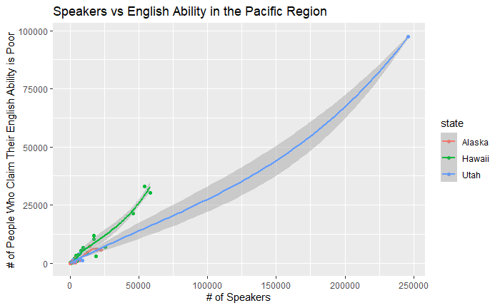

```r
# The color aeesthetic is by the state variable and I overlayed geom_point() with geom_smooth(). I also added x and y-axis labels and a title for the visual
Pacific %>%
  ggplot(aes(x = NumberSpeakers, y = EnglishNotVeryWell, color = state)) +
  geom_point() +
  geom_smooth() +
  xlab("# of Speakers") +
  ylab("# of People Who Claim Their English Ability is Poor") +
  labs(title = "Speakers vs English Ability in the Pacific Region")
```

But it’s hard to see the data for Alaska since Utah has a huge outlier, so what if we limited the x-axis and y-axis ranges to take out the outlier?

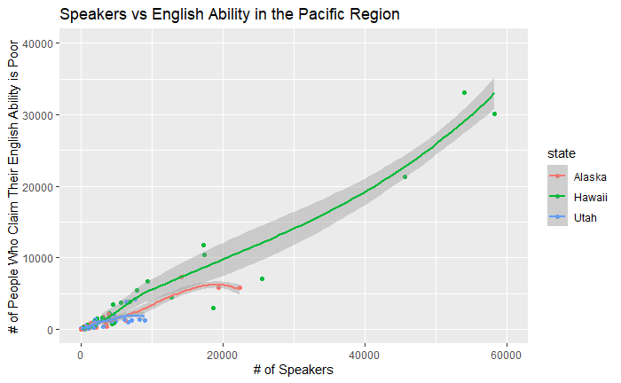

```r
# Here I just added limitaitons for the x and y-axis value ranges. The x-axis is limited to 0 to 60000 and the y-axis is limited to 0 to 40000. This takes out the extreme data point (maybe an outlier but maybe not) that we saw earlier.
Pacific %>%
  ggplot(aes(x = NumberSpeakers, y = EnglishNotVeryWell, color = state)) +
  geom_point() +
  geom_smooth() +
  xlim(0, 60000) +
  ylim(0, 40000) +
  xlab("# of Speakers") +
  ylab("# of People Who Claim Their English Ability is Poor") +
  labs(title = "Speakers vs English Ability in the Pacific Region")
```

So now that we can see the Alaska and Hawaii data more clearly, we see that there’s a general positive trend, meaning the greater the number of speakers, the more people claim their English ability is poor. Unfortunately, it seems like there’s a greater error range for Hawaii than Alaska and Alaska’s curve actually starts curving down at the end. So can we conclude that the higher the number of speakers of a language, the more number of peopel who claim their English ability is poor? We need to look at more visualizations.

What about for the other regions?

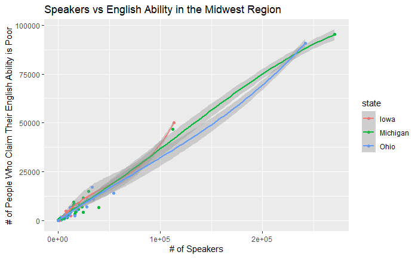

```r
Midwest %>%
  ggplot(aes(x = NumberSpeakers, y = EnglishNotVeryWell, color = state)) +
  geom_point() +
  geom_smooth() +
  xlab("# of Speakers") +
  ylab("# of People Who Claim Their English Ability is Poor") +
  labs(title = "Speakers vs English Ability in the Midwest Region")
```

For the Midwest region, the lines are clearer and show an evident positive relationship, but let’s check the other two regions as well.

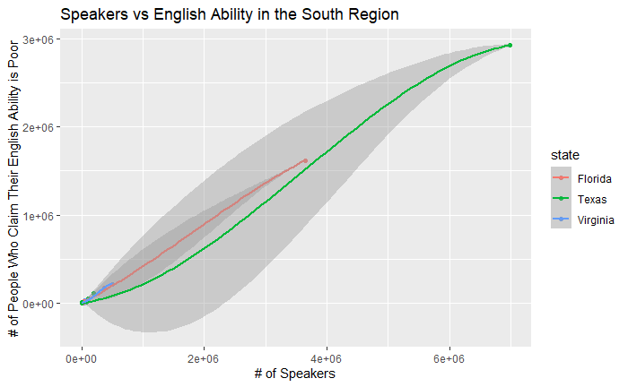

```r
South %>%
  ggplot(aes(x = NumberSpeakers, y = EnglishNotVeryWell, color = state)) +
  geom_point() +
  geom_smooth() +
  xlab("# of Speakers") +
  ylab("# of People Who Claim Their English Ability is Poor") +
  labs(title = "Speakers vs English Ability in the South Region")
```

It seems that the error range is much larger for Texas than any other states we’ve seen so far. It’s a bit concerning, although all three states still follow the positive relationship we saw earlier.

I decided to limit the ranges to show a clearer image and the pattern differences. It’s very interesting to look at, but each seems to all hold a positive relationship, just some not as steep as others.

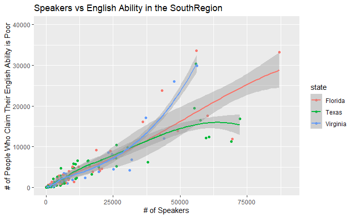

```r
South %>%
  ggplot(aes(x = NumberSpeakers, y = EnglishNotVeryWell, color = state)) +
  geom_point() +
  geom_smooth() +
  xlab("# of Speakers") +
  ylab("# of People Who Claim Their English Ability is Poor") +
  labs(title = "Speakers vs English Ability in the SouthRegion") +
  xlim(0, 90000) +
  ylim(0, 40000)
```

Let’s take a look at the last region, Northeast.

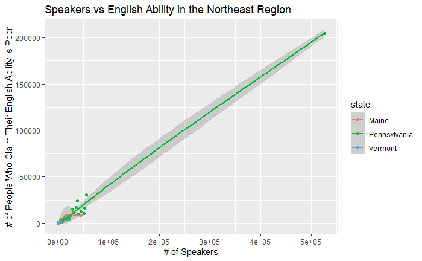

```r
Northeast %>%
  ggplot(aes(x = NumberSpeakers, y = EnglishNotVeryWell, color = state)) +
  geom_point() +
  geom_smooth() +
  xlab("# of Speakers") +
  ylab("# of People Who Claim Their English Ability is Poor") +
  labs(title = "Speakers vs English Ability in the Northeast Region")
```

Although I can’t quite see the Vermont data and the Maine data seems to be positive and then plateaus, the Pennsylvania shows a clear positive relationship with a small error range. I think from all these graphs we saw, it may be safe to safe that there is indeed a positive relationship between the number of speakers of a language and the number of people of that language who claim their English ability is poor.

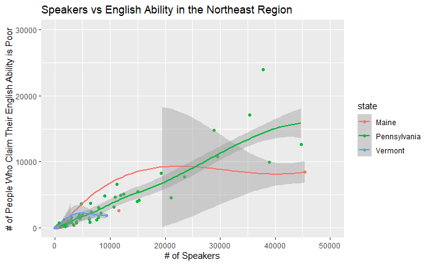

```r
Northeast %>%
  ggplot(aes(x = NumberSpeakers, y = EnglishNotVeryWell, color = state)) +
  geom_point() +
  geom_smooth() +
  xlab("# of Speakers") +
  ylab("# of People Who Claim Their English Ability is Poor") +
  labs(title = "Speakers vs English Ability in the Northeast Region") +
  xlim(0, 50000) +
  ylim(0, 30000)
```

Let’s see if the same pattern is apparent in the overall nation data.

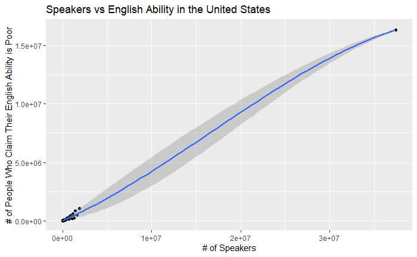

```r
Nation %>%
  ggplot(aes(x = NumberSpeakers, y = EnglishNotVeryWell)) +
  geom_point() +
  geom_smooth() +
  xlab("# of Speakers") +
  ylab("# of People Who Claim Their English Ability is Poor") +
  labs(title = "Speakers vs English Ability in the United States")
```

Although the error range is slightly larger than some individual states, overall, there seems to be a somewhat positive relationship, but I’d like to see what will happen if I limit the x and y-axis ranges.

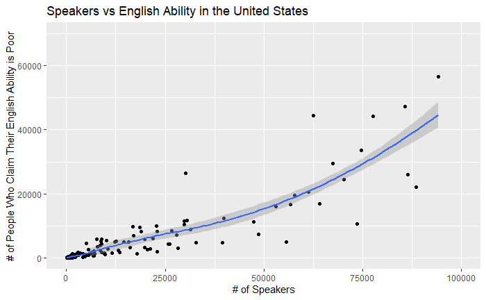

```r
Nation %>%
  ggplot(aes(x = NumberSpeakers, y = EnglishNotVeryWell)) +
  geom_point() +
  geom_smooth() +
  xlab("# of Speakers") +
  ylab("# of People Who Claim Their English Ability is Poor") +
  labs(title = "Speakers vs English Ability in the United States") +
  xlim(0, 100000) +
  ylim(0, 70000)
```

Once we zoomed in on the graph, we see a very interesting pattern. The datapoints give us a pattern that’s almost parabolic. It’s still a positive relationship, but much different than what we expected from when we included all the datapoints.

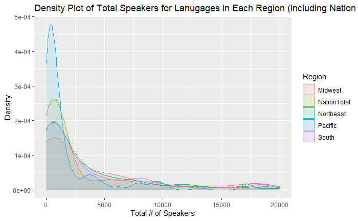

```r
# I had to use gather() to change my data table to a longer format before I could output a graph that I wanted.
# I then graphed a density plot for the total number of speakers for each language with the line colours differentiating based on region.
Total %>%
  gather(Pacific, Midwest, South, Northeast, NationTotal, key = Region, value = SpeakerTotal) %>%
  ggplot(aes(SpeakerTotal, colour = Region, fill = Region)) +
  geom_density(alpha = 0.1) +
  xlim(0, 20000) +
  xlab("Total # of Speakers") +
  ylab("Density") +
  labs(title = "Density Plot of Total Speakers for Lanugages in Each Region (including Nation total)")
```

This output is actually very interesting to see because it shows that the density for smaller number of speakers is much higher than everything else. The higher the number of speakers goes, the smaller the density. I think this is important to know because it affects how we can ultimately interpret the graphs we saw above with the positive relationships, especially when we included all the data points. It shows how easily an “outlier” datapoint for a large number of speakers could affect the plot, therefore, zooming in (like what I did for a couple graphs), actually really helps us see the patterns more clearly.

Overall, the relationships are still all positive, but when we zoomed in, we saw how much they could differentiate (whether it’s based on steepness or if it almost looks like a parabolic curve, or even plateaus, etc.).

I want to create another visualization using the SouthSum data table, but I realized that the current format it’s in is good for looking at and doing data transformations or reductions, but not good for graphing. So I had to use **gather()** to change the format from wide to long before I could graph the data (similar to what I did for the Total data table).

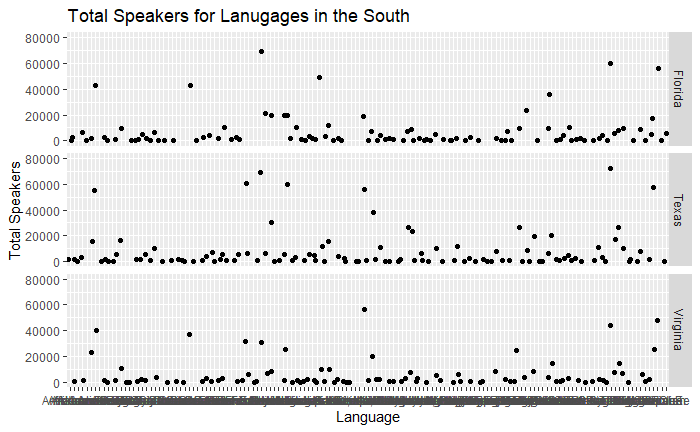

```r
SouthSum %>%
  gather(Florida, Texas, Virginia, key = state, value = TotalSpeakers) %>%
  ggplot(aes(x = Language, y = TotalSpeakers)) +
  geom_jitter() +
  facet_grid(state ~ .) +
  ylim(0, 80000) +
  ylab("Total Speakers") +
  labs(title = "Total Speakers for Lanugages in the South")
```

Although in the output, you cannot see the specific names of languages since there are so many to the point that they overlap, but I think it’s okay because I’m getting an overall view of the differences beetween the total speakers for each langauge for the states Florida, Texas, and Virginia. For the point of this report, there’s no need to see the actual names of the languages, since I just wanted to see the comparison of the total number of speakers. This helps me see the patterns between the languages.

The graph below shows the same idea as the one above, but for each region, as well as the Nation. This also helps me visualize the patterns in total number of speakers for languages and how it differs based on region, which helps me understand why the first couple of plots I looked at had such interesting error ranges.

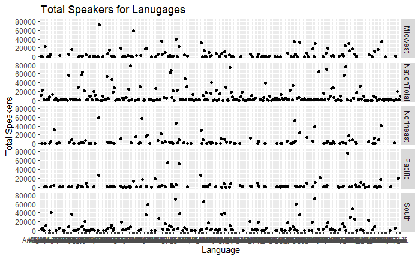

```r
Total %>%
  gather(Pacific, Midwest, South, Northeast, NationTotal, key = Region, value = SpeakerTotal) %>%
  ggplot(aes(x = Language, y = SpeakerTotal)) +
  geom_jitter() +
  facet_grid(Region ~ .) +
  ylim(0, 80000) +
  ylab("Total Speakers") +
  labs(title = "Total Speakers for Lanugages")
```

## Conclusion/Final Thoughts

So what did I learn from all the data wrangling and visualizations I did?

From the data visualizations, I was able to see that there is a generally positive relaitonship between the total number of speakers and the number of people who claim their English ability is poor for langauges, no matter the region. Some regions have larger error ranges and when you zoom in, the relationships are slightly different. All the relationships are positive, some are steeper or look more parabolic, while others seem to plateau, etc.

There are also languages that seem to have larger groups of speakers, no matter hte region as well (with some exceptions).

If I were to clean the rest of the data and do analysis and create visualizations on a more complete set of data, then maybe we’d have stronger evidence. Until then, although we see a positive relationship that backs up my original assumption, I cannot be very certain since I only included 3 states in each region.

For future work, I’d like to see if the patterns since in the overall Nation data will be closer to what we see in each region if all states are included. Note that I would also have to add in the territories, like Puerto Rico.

Also, note that the English ability is subjective since the surveyed people had to rate themselves and anyone else in their household together. The Census Bureau didn’t individually survey every single person, rather they surveyed by household so that rating could be a bit biased and/or skewed. Remember that I stated before I may be able to conclude with a higher confidence if we could collect English ability in a more objective way, via scientific and statistical analysis of their performance on some tasks. But then this would tie into more research that may not be necessarily done by the Census Bureau.

Throughout this process, I learned how difficult data cleaning can be depending on the form the data is in. But once data is cleaned into a tidy format, it makes data wrangling and data visualizations a lot easier. As you saw, I could easily manipulate my data (i.e. using spread() or gather(), sum(), etc.) to get more insights and create data graphics to explore different parts of my research question.